# PS3

### load libraries

```r
library(ggplot2)
library(dplyr)
library(statsr)
library(tidyr)
```

# Author: Pinlu Chen

# Github repository: https://github.com/pinlu-chen/Problem-Set-3

# Abstract

### Established in 1985, the Canadian General Social Survey (GSS) programm was developed as a series of independent annual voluntary intersectoral surveys, each covering a single topic. The overall objectives of the programm were and continue to be to collect data on social trends in order to monitor changes in the living conditions and well-being of Canadians, and to provide information on specific social policy issues.

### Recent surveys of GSS programs focused on seven topics: life at work and at home; families; care and receiving care; giving, volunteering and participating; victimization; social identity and time use.

# Introduction

### The General social survey collects information from people aged 15 and older in ten provinces of Canada, with the exception of permanent residents in institutions. The victimization cycle, last collected in 2009 and 2014, was also conducted in the territories of Canada.

### The sample size for CSS has changed over time. Prior to 1998, the target final sample size for each GSS cycle was approximately 10,000. This figure was increased in 1999 to a target of 25,000 people until 2015, when this figure was reduced to 22,000 people, and then further reduced to 20,000 people starting in 2016.

# Data

### First, we clean the downloaded GSS data by using the given R script

### After cleaning the downloaded GSS data, we load the clean gss.csv into R dataframe

```r
df <- read.csv("gss.csv")
```

### Display some rows

```r
head(df)
```

|  | caseid | age | age_first_child | age_youngest_child_under_6 | total_children | age_start_relationship | age_at_first_marriage | age_at_first_birth | distance_between_houses | age_youngest_child_returned_work | feelings_life | sex | place_birth_canada | place_birth_father | place_birth_mother | place_birth_macro_region | place_birth_province | year_arrived_canada | province | region | pop_center | marital_status | aboriginal | vis_minority | age_immigration | landed_immigrant | citizenship_status | education | own_rent | … |
| --- | --- | --- | --- | --- | --- | --- | --- | --- | --- | --- | --- | --- | --- | --- | --- | --- | --- | --- | --- | --- | --- | --- | --- | --- | --- | --- | --- | --- | --- | --- |
| 1 | 1 | 52.7 | 27 | NA | 1 | NA | NA | 25.9 | 30 | NA | 8 | Female | Born in Canada | Born in Canada | Born in Canada | NA | Quebec | NA | Quebec | Quebec | Larger urban population centres (CMA/CA) | Single, never married | No | Not a visible minority | NA | NA | By birth | High school diploma or a high school equivalency certificate | Owned by you or a member of this household, even if it i... | … |
| 2 | 2 | 51.1 | 33 | NA | 5 | NA | NA | NA | NA | NA | 10 | Male | Born in Canada | Born in Canada | Born in Canada | NA | Ontario | NA | Manitoba | Prairie region | Larger urban population centres (CMA/CA) | Married | No | Not a visible minority | NA | NA | By birth | Trade certificate or diploma | Owned by you or a member of this household, even if it i... | … |
| 3 | 3 | 63.6 | 40 | NA | 5 | NA | NA | 23.2 | NA | NA | 8 | Female | Born in Canada | Born in Canada | Born in Canada | NA | Ontario | NA | Ontario | Ontario | Rural areas and small population centres (non CMA/CA) | Married | No | Not a visible minority | NA | NA | By birth | Bachelor's degree (e.g. B.A., B.Sc., LL.B.) | Owned by you or a member of this household, even if it i... | … |
| 4 | 4 | 80.0 | 56 | NA | 1 | NA | NA | 27.3 | NA | NA | 10 | Female | Born in Canada | Born outside Canada | Born outside Canada | NA | Alberta | NA | Alberta | Prairie region | Larger urban population centres (CMA/CA) | Married | No | Not a visible minority | NA | NA | By birth | High school diploma or a high school equivalency certificate | Owned by you or a member of this household, even if it i... | … |
| 5 | 5 | 28.0 | NA | NA | 0 | 25.3 | NA | NA | NA | NA | 8 | Male | Born in Canada | Born in Canada | Born in Canada | NA | Quebec | NA | Quebec | Quebec | Larger urban population centres (CMA/CA) | Living common-law | No | Not a visible minority | NA | NA | By birth | College, CEGEP or other non-university certificate or di... | Rented, even if no cash rent is paid | … |
| 6 | 6 | 63.0 | 37 | NA | 2 | NA | NA | 25.8 | NA | NA | 9 | Female | Born in Canada | Born in Canada | Born in Canada | NA | Quebec | NA | Quebec | Quebec | Larger urban population centres (CMA/CA) | Married | No | Not a visible minority | NA | NA | By birth | High school diploma or a high school equivalency certificate | Owned by you or a member of this household, even if it i... | … |

### Let’s check all the column names in the dataset

```r
names(df)
```

```
##  [1] "caseid"                           "age"
##  [3] "age_first_child"                  "age_youngest_child_under_6"
##  [5] "total_children"                   "age_start_relationship"
##  [7] "age_at_first_marriage"            "age_at_first_birth"
##  [9] "distance_between_houses"          "age_youngest_child_returned_work"
## [11] "feelings_life"                    "sex"
## [13] "place_birth_canada"               "place_birth_father"
## [15] "place_birth_mother"               "place_birth_macro_region"
## [17] "place_birth_province"             "year_arrived_canada"
## [19] "province"                         "region"
## [21] "pop_center"                       "marital_status"
## [23] "aboriginal"                       "vis_minority"
## [25] "age_immigration"                  "landed_immigrant"
## [27] "citizenship_status"               "education"
## [29] "own_rent"                         "living_arrangement"
```

[output cut: 26 more lines]

### As we see there are 81 total columns.

### Data Summary

```r
summary(df)
```

```
##      caseid           age        age_first_child age_youngest_child_under_6
##  Min.   :    1   Min.   :15.00   Min.   : 0.00   Min.   :0.000
##  1st Qu.: 5151   1st Qu.:37.30   1st Qu.:15.00   1st Qu.:1.000
##  Median :10302   Median :54.20   Median :32.00   Median :2.000
##  Mean   :10302   Mean   :52.19   Mean   :30.57   Mean   :2.412
##  3rd Qu.:15452   3rd Qu.:66.78   3rd Qu.:44.00   3rd Qu.:4.000
##  Max.   :20602   Max.   :80.00   Max.   :60.00   Max.   :5.000
##                                  NA's   :6835    NA's   :18488
##  total_children  age_start_relationship age_at_first_marriage
##  Min.   :0.000   Min.   :18.00          Min.   :15.0
##  1st Qu.:0.000   1st Qu.:25.00          1st Qu.:20.5
##  Median :2.000   Median :30.50          Median :22.8
##  Mean   :1.679   Mean   :33.63          Mean   :24.1
##  3rd Qu.:3.000   3rd Qu.:40.62          3rd Qu.:26.4
##  Max.   :7.000   Max.   :60.00          Max.   :50.0
##  NA's   :19      NA's   :18566          NA's   :15248
##  age_at_first_birth distance_between_houses age_youngest_child_returned_work
##  Min.   :18.00      Min.   : 0.00           Min.   : 0.200
##  1st Qu.:22.80      1st Qu.: 4.00           1st Qu.: 0.500
##  Median :26.40      Median :10.00           Median : 6.000
##  Mean   :26.86      Mean   :17.13           Mean   : 6.589
##  3rd Qu.:30.30      3rd Qu.:24.75           3rd Qu.:12.000
##  Max.   :45.00      Max.   :90.00           Max.   :48.000
##  NA's   :7865       NA's   :19476           NA's   :19466
##  feelings_life        sex            place_birth_canada place_birth_father
##  Min.   : 0.000   Length:20602       Length:20602       Length:20602
##  1st Qu.: 7.000   Class :character   Class :character   Class :character
##  Median : 8.000   Mode  :character   Mode  :character   Mode  :character
##  Mean   : 8.094
##  3rd Qu.: 9.000
##  Max.   :10.000
##  NA's   :271
##  place_birth_mother place_birth_macro_region place_birth_province
##  Length:20602       Length:20602             Length:20602
##  Class :character   Class :character         Class :character
##  Mode  :character   Mode  :character         Mode  :character
##
##
##
##
```

[output cut: 137 more lines]

```
##  Min.   :0.000   Min.   :0.000   Length:20602       Length:20602
##  1st Qu.:0.000   1st Qu.:0.000   Class :character   Class :character
##  Median :0.000   Median :0.000   Mode  :character   Mode  :character
##  Mean   :0.055   Mean   :0.055
##  3rd Qu.:0.000   3rd Qu.:0.000
##  Max.   :1.000   Max.   :1.000
##  NA's   :20057   NA's   :20057
##     is_male       main_activity    age_diff         number_total_children_known
##  Min.   :0.0000   Mode:logical   Length:20602       Min.   :0.0000
##  1st Qu.:0.0000   NA's:20602     Class :character   1st Qu.:0.0000
##  Median :0.0000                  Mode  :character   Median :0.0000
##  Mean   :0.4562                                     Mean   :0.4123
##  3rd Qu.:1.0000                                     3rd Qu.:1.0000
##  Max.   :1.0000                                     Max.   :1.0000
##
```

# Model

```r
###model <- lm(income_family ~ age + education + sex + province + occupation, data = df)
```

# Results

```r
summary(df$age)
```

```
##    Min. 1st Qu.  Median    Mean 3rd Qu.    Max.
##   15.00   37.30   54.20   52.19   66.78   80.00
```

```r
table(df$sex)
```

```
##
## Female   Male
##  11203   9399
```

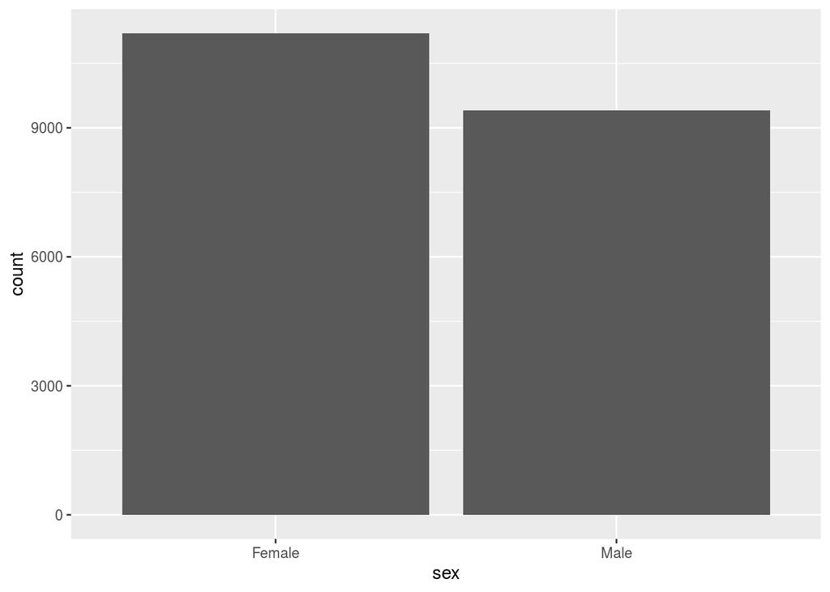

```r
ggplot(data = df) +
  geom_bar(mapping = aes(x = sex))
```

# Number of respondents per province

```r
table(df$province)
```

```
##
##                   Alberta          British Columbia                  Manitoba
##                      1728                      2522                      1192
##             New Brunswick Newfoundland and Labrador               Nova Scotia
##                      1337                      1094                      1425
##                   Ontario      Prince Edward Island                    Quebec
##                      5621                       708                      3822
##              Saskatchewan
##                      1153
```

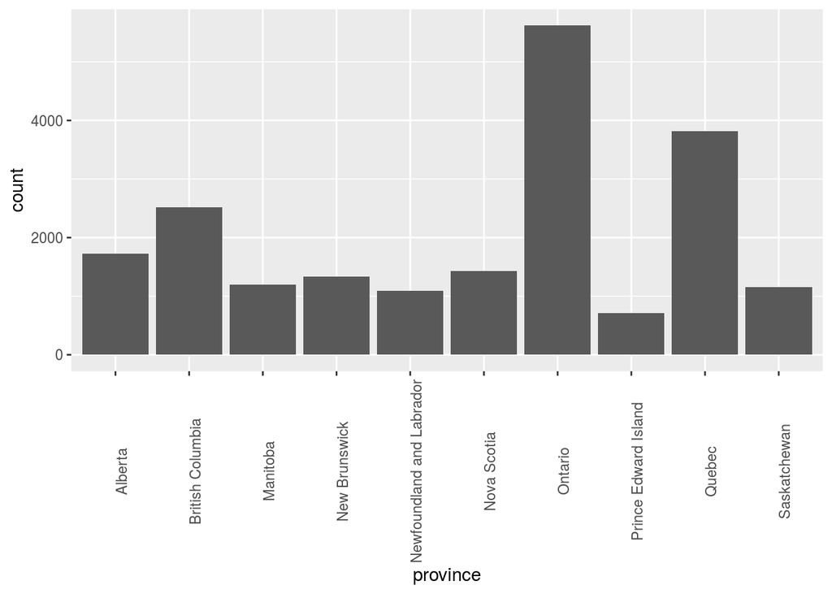

```r
ggplot(data = df) +
  geom_bar(mapping = aes(x = province)) +
  theme(axis.text.x = element_text(angle = 90))
```

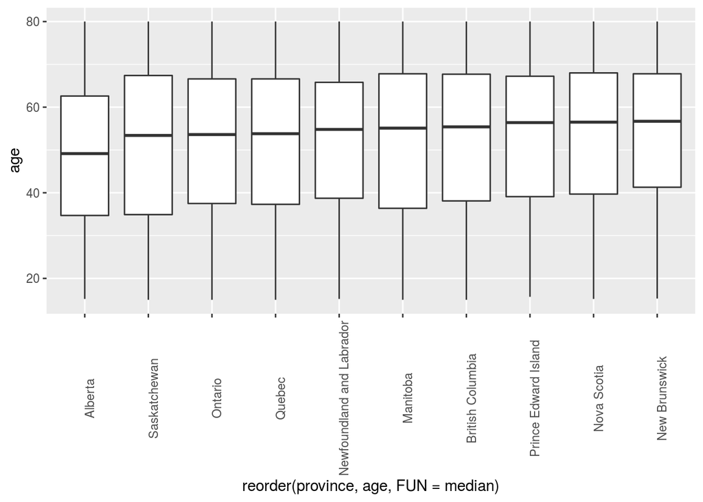

```r
ggplot(data = df) +
  geom_boxplot(mapping = aes(x = reorder(province, age, FUN = median), y = age)) +
  theme(axis.text.x = element_text(angle = 90))
```

### Education status of respondents

```r
table(df$education)
```

```
##
##                  Bachelor's degree (e.g. B.A., B.Sc., LL.B.)
##                                                         3753
##  College, CEGEP or other non-university certificate or di...
##                                                         4566
## High school diploma or a high school equivalency certificate
##                                                         4848
##              Less than high school diploma or its equivalent
##                                                         3036
##                                 Trade certificate or diploma
##                                                         1483
## University certificate or diploma below the bachelor's level
##                                                          732
##  University certificate, diploma or degree above the bach...
##                                                         1843
```

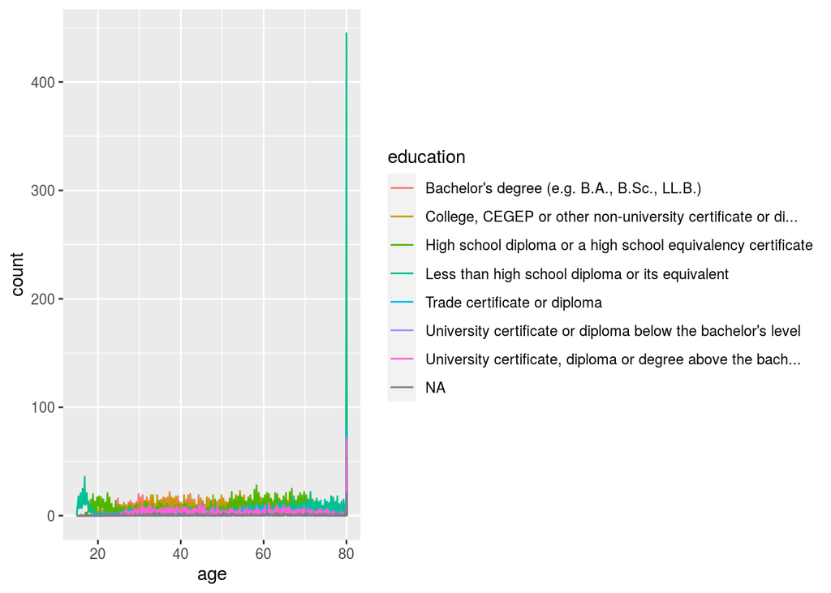

```r
ggplot(data = df, mapping = aes(x = age, colour = education)) +
  geom_freqpoly(binwidth = 0.1)
```

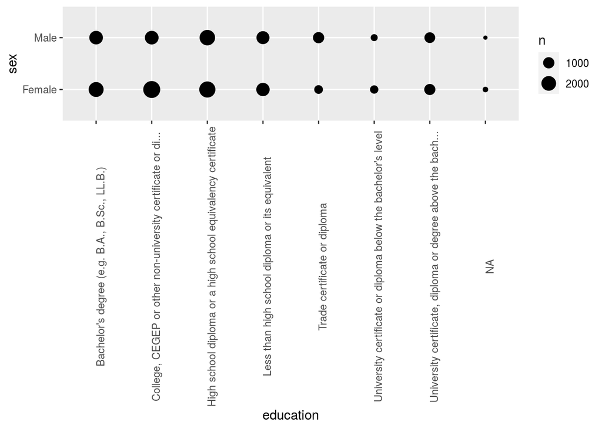

```r
ggplot(data = df) +
  geom_count(mapping = aes(x = education, y = sex)) +
  theme(axis.text.x = element_text(angle = 90))
```

```r
table(df$occupation)
```

```
##
##           Business, finance, and administration occupations
##                                                        2205
##                                          Health occupations
##                                                        1038
##                                      Management occupations
##                                                        1242
##        Natural and applied sciences and related occupations
##                                                        1043
## Natural resources, agriculture and related production oc...
##                                                         337
##           Occupations in art, culture, recreation and sport
##                                                         452
## Occupations in education, law and social, community and ...
##                                                        1835
##                  Occupations in manufacturing and utilities
##                                                         474
##                               Sales and service occupations
##                                                        2912
## Trades, transport and equipment operators and related oc...
##                                                        1694
##                                                   Uncodable
##                                                          73
```

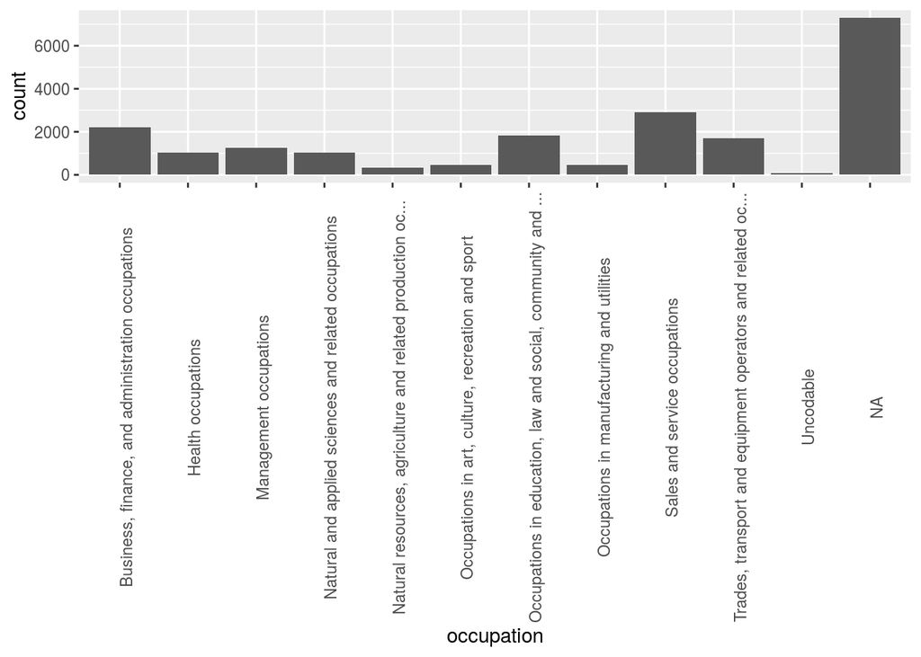

```r
ggplot(data = df) +
  geom_bar(mapping = aes(x = occupation)) +
  theme(axis.text.x = element_text(angle = 90))
```

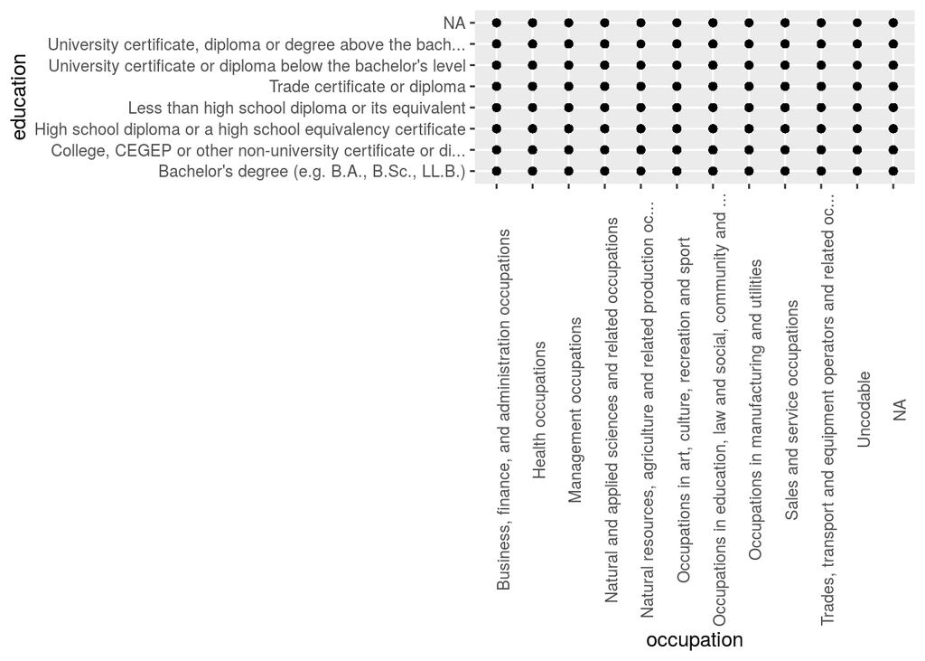

```r
ggplot(data = df) +
  geom_point(mapping = aes(y = education, x = occupation)) +
  theme(axis.text.x = element_text(angle = 90))
```

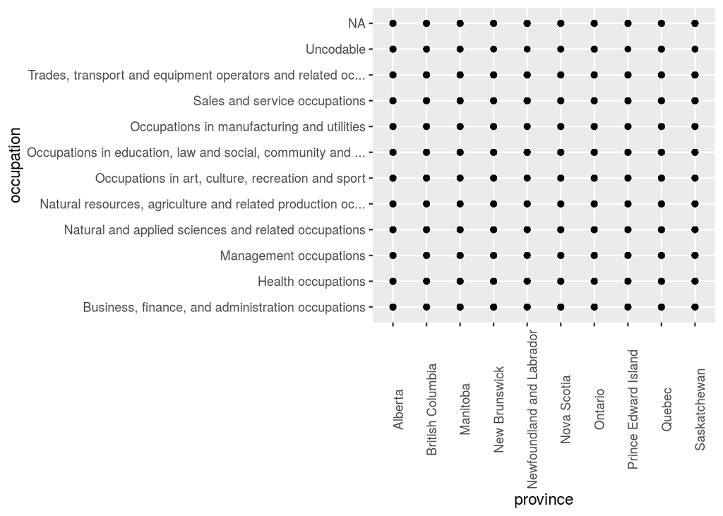

```r
ggplot(data = df) +
  geom_point(mapping = aes(x = province, y = occupation)) +
  theme(axis.text.x = element_text(angle = 90))
```

```r
table(df$aboriginal)
```

```
##
## Don't know         No        Yes
##         86      15869        792
```

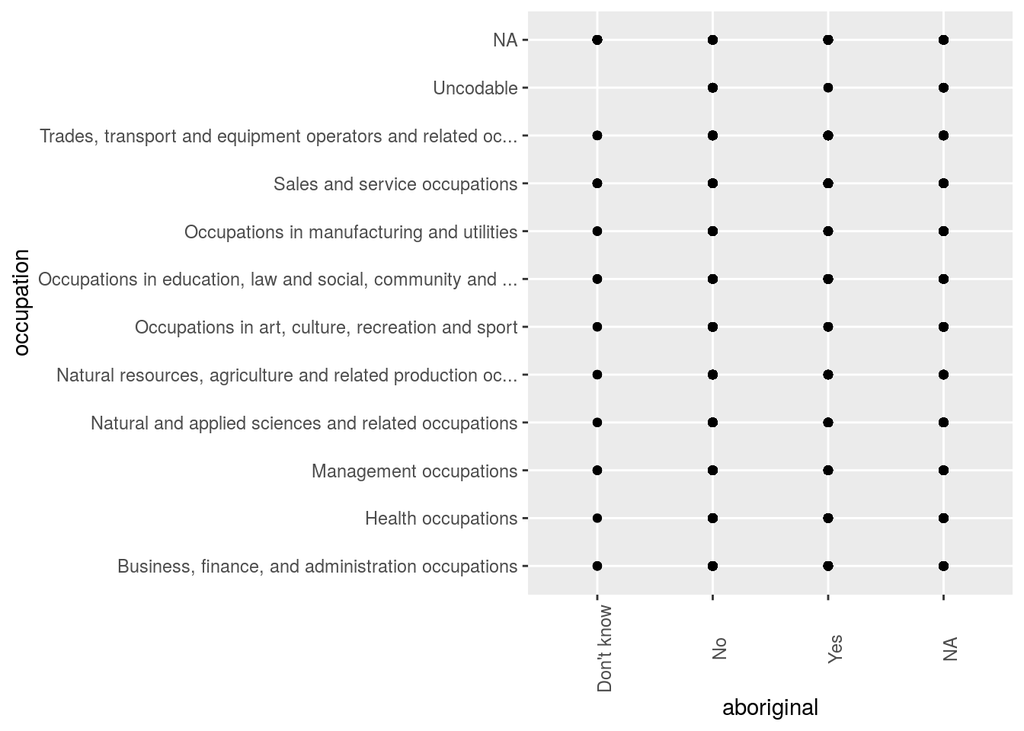

```r
ggplot(data = df) +
  geom_point(mapping = aes(x = aboriginal, y = occupation)) +
  theme(axis.text.x = element_text(angle = 90))
```

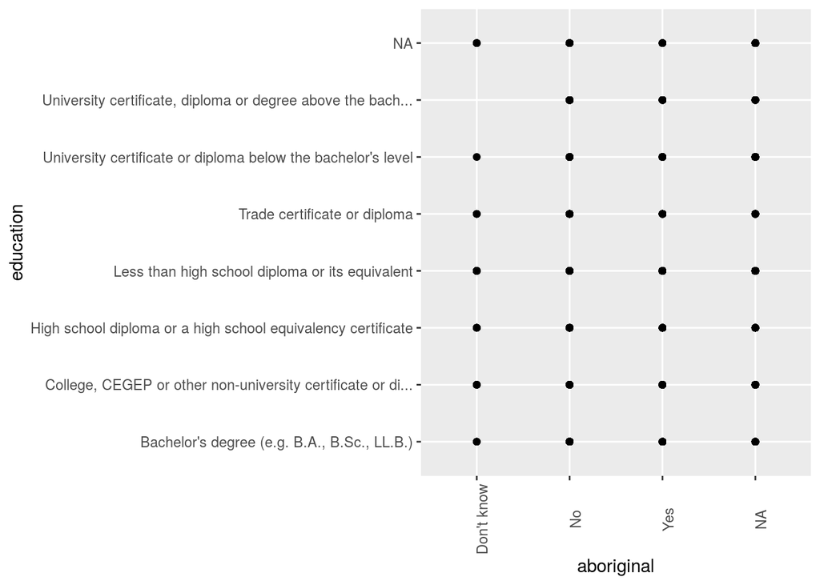

```r
ggplot(data = df) +
  geom_point(mapping = aes(x = aboriginal, y = education)) +
  theme(axis.text.x = element_text(angle = 90))
```

### Relationship between income and age

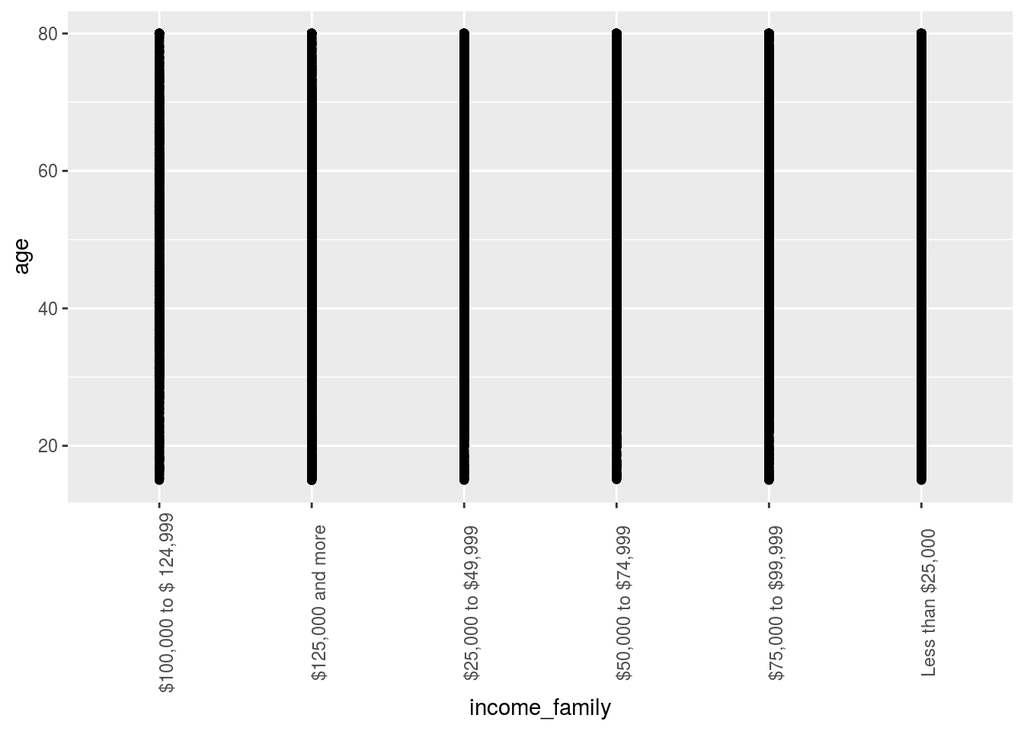

```r
ggplot(data = df) +
  geom_point(mapping = aes(x = income_family, y = age)) +
  theme(axis.text.x = element_text(angle = 90))
```

### Relationship between income and sex

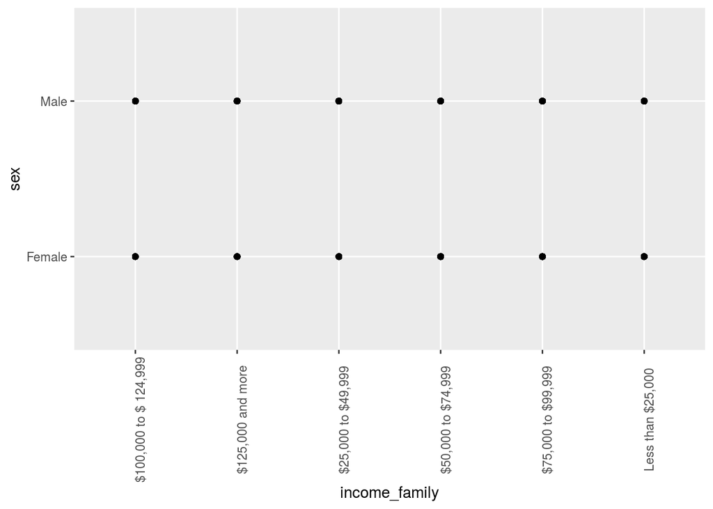

```r
ggplot(data = df) +
  geom_point(mapping = aes(x = income_family, y = sex)) +
  theme(axis.text.x = element_text(angle = 90))
```

### Relationship between income and province

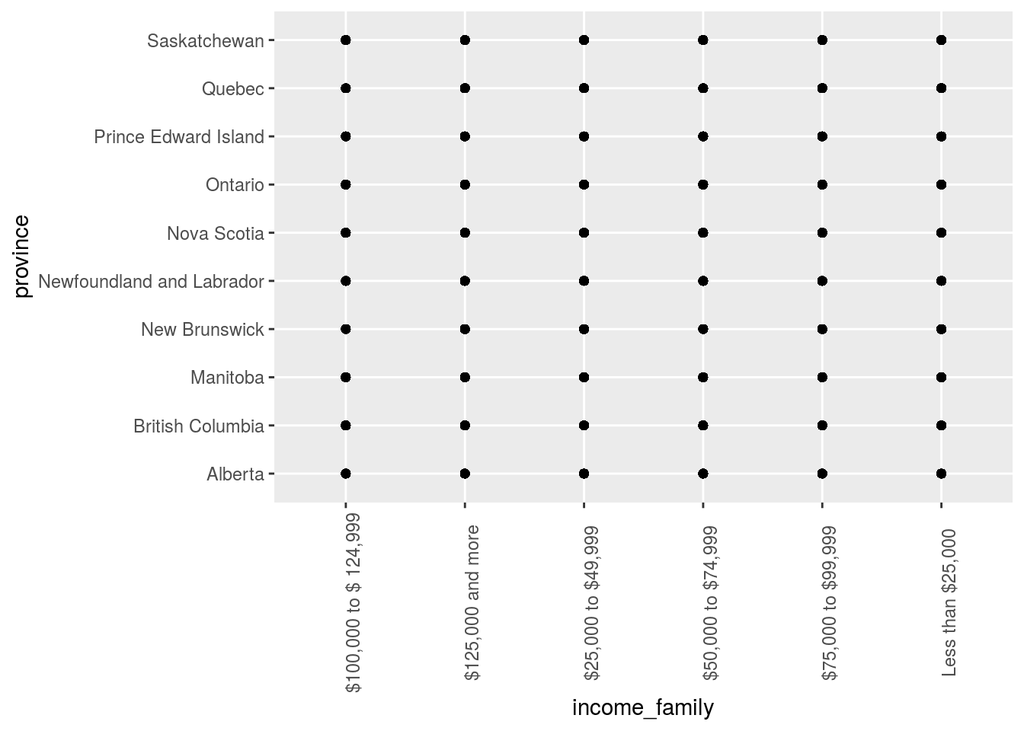

```r
ggplot(data = df) +
  geom_point(mapping = aes(x = income_family, y = province)) +
  theme(axis.text.x = element_text(angle = 90))
```

# Discussion

### We see that minimum age of the respondents is 15, mean age is 52.19, and maximum age is 80.

# References

### Statistics Canada https://www150.statcan.gc.ca/n1/pub/89f0115x/89f0115x2019001-eng.htm